# Wrangling & Analysis Of Twitter User WeRateDogs archive data

The goal of the project was to wrangle WeRateDogs Twitter data to create interesting and trustworthy analyses and visualizations using python.

*A typical post from the @dog_rates twitter user:*

[figure not shown]

> With the rapid expansion of real-world data, it is vital to get and organize large amounts of correctly cleaned data for analysis.

### What is Data wrangling

Data Wrangling is the process of gathering, assessing and cleaning data for easy and better analysis and visualization.

Gathering data differs from project to project, it can be manually downloading the data file and uploading it into your project workspace, or it can be programmitically downloading the file using python's Request library, and it can also be querying data from APIs. In this project I used all three gathering methods to get different pieces of datasets.

Data can be assessed through two types of assessments: Visual and Programmatic. **Visual Assessment** is just opening the dataframe and looking through its entirety either in pandas, a text editor or a spreadsheet application. **Programmatic Assessment** consistes of using codes to view certain parts of the dataframe, such as using python functions and methods to summarize the data. Either of the two types of assessments are used to detect and later document quality or tidiness issues with your data.  
In this project I used both types of assessment to document quality and tidiness issues in the datasets.

Cleaning data consists of using python functions to fix the documented issues and combining data pieces resulting in a master clean dataframe that will make the analysis easy and clear.

## Analysis And Visualization of WeRateDogs Data

> After wrangling the datasets I based my analysis with number 1 prediction dog breed and found the following insights:

#### The highest rated prediction 1 dog breed is the clumber with a mean rating of 27/10

The dog breed that received the highest rating from the user was a clumber.

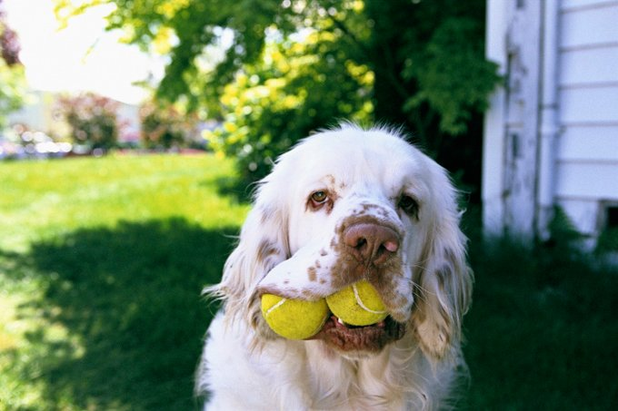

I mean look at all this cuteness, the ratings were definitely spot on.

#### The most liked dog breed is the English_springer with 29K mean likes

The English Springer got the most likes from the followers of the user with about 29 thousand average likes

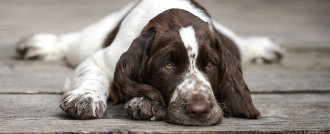

That look just melts a heart, completely deserving of a thousand thumbs.

#### The most popular dog breed is the English_springer with 12K mean retweets

The most retweeted posts of the @dog_rates user was the English Springer, the above picture proves why. But if you are still reluctant here's more

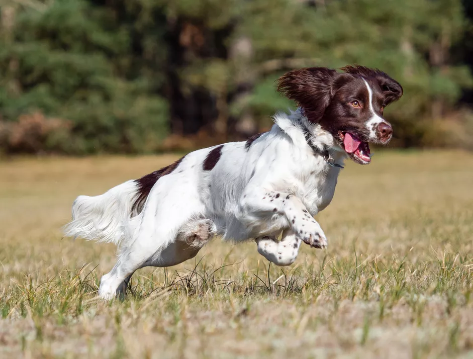

I absolutely have a dog fever right now. Paw friends are just the cutest!

> Finally I made the following plot to visualize the relationship between the prediction 1 dog breeds and the favourite counts

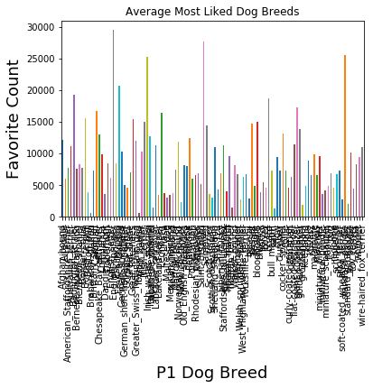

> My x-axis was cluttered because our paw furry friends come in many kinds of breeds and they are all heart-melting and deserve lots of thumbs